# PCA_for_Visualization

```python
%matplotlib inline
import numpy as np
import matplotlib.pyplot as plt
import seaborn as sns; sns.set()
```

### Dimensionality Reduction for Visualization Problems

### PCA : Hand-written digits

The usefulness of the dimensionality reduction may not be entirely apparent in only two dimensions, but becomes much more clear when looking at high-dimensional data.

```python
from sklearn.datasets import load_digits

digits = load_digits()
digits.keys()
```

```
dict_keys(['data', 'target', 'target_names', 'images', 'DESCR'])
```

The images data is a three-dimensional array: 1,797 samples each consisting of an 8 × 8 grid of pixels.

```python
digits.images.shape
```

```
(1797, 8, 8)
```

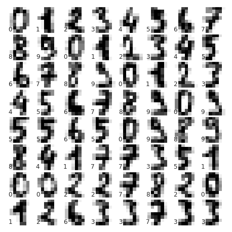

```python
# Visualize some data points
# set up the figure
fig = plt.figure(figsize=(6, 6))  # figure size in inches
fig.subplots_adjust(left=0, right=1, bottom=0, top=1, hspace=0.05, wspace=0.05)

# plot the digits: each image is 8x8 pixels
for i in range(64):
    ax = fig.add_subplot(8, 8, i + 1, xticks=[], yticks=[])
    ax.imshow(digits.images[i], cmap=plt.cm.binary, interpolation='nearest')

    # label the image with the target value
    ax.text(0, 7, str(digits.target[i]))
```

The data consists of 8×8 pixel images, meaning that they are 64-dimensional. To gain some intuition into the relationships between these points, we can use PCA to project them to a more manageable number of dimensions, say two:

```python
from sklearn.decomposition import PCA

pca = PCA(2)  # project from 64 to 2 dimensions
projected = pca.fit_transform(digits.data)
print(digits.data.shape)
print(projected.shape)
```

```
(1797, 64)
(1797, 2)
```

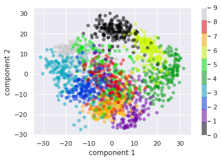

```python
# We can now plot the first two principal components
# of each point to learn about the data:
plt.scatter(projected[:, 0], projected[:, 1],
            c=digits.target, edgecolor='none', alpha=0.5,
            cmap=plt.cm.get_cmap('nipy_spectral', 10))
plt.xlabel('component 1')
plt.ylabel('component 2')
plt.colorbar();
```

### Choosing the number of components

A vital part of using PCA in practice is the ability to estimate how many components are needed to describe the data. This can be determined by looking at the cumulative explained variance ratio as a function of the number of components:

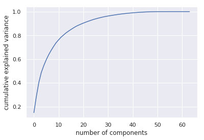

```python
pca = PCA().fit(digits.data)
plt.plot(np.cumsum(pca.explained_variance_ratio_))
plt.xlabel('number of components')
plt.ylabel('cumulative explained variance');
```

### PCA : EigenFaces

Let's take a look at the facial recognition problem. We will use the `Labeled Faces in the Wild` dataset, which consists of several thousand collated photos of various public figures.

```python
from sklearn.datasets import fetch_lfw_people
faces = fetch_lfw_people(min_faces_per_person=50)
print(faces.target_names)
print(faces.images.shape)
```

```
['Ariel Sharon' 'Colin Powell' 'Donald Rumsfeld' 'George W Bush'
 'Gerhard Schroeder' 'Hugo Chavez' 'Jacques Chirac' 'Jean Chretien'
 'John Ashcroft' 'Junichiro Koizumi' 'Serena Williams' 'Tony Blair']
(1560, 62, 47)
```

Each image contains [62×47] or nearly 3,000 pixels.

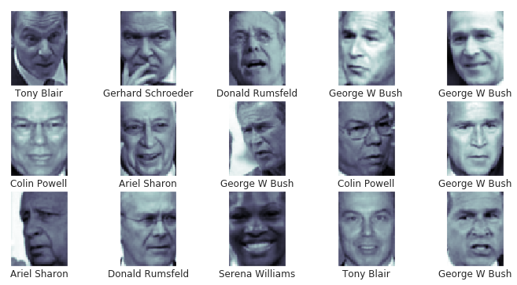

```python
# plot a few of these faces to see what we're working with:
fig, ax = plt.subplots(3, 5, figsize=(12,6))
for i, axi in enumerate(ax.flat):
    axi.imshow(faces.images[i], cmap='bone')
    axi.set(xticks=[], yticks=[],
            xlabel=faces.target_names[faces.target[i]])
```

We could proceed by simply using each pixel value as a feature, but often it is more effective to use some sort of preprocessor to extract more meaningful features; here we will use a `PCA` to extract 150 fundamental components to feed into our support vector machine (`SVM`) classifier. We can do this most straightforwardly by packaging the preprocessor and the classifier into a single `pipeline`:

```python
from sklearn.svm import SVC
from sklearn.decomposition import PCA
from sklearn.pipeline import make_pipeline

pca = PCA(n_components=150, svd_solver='randomized',
                    whiten=True, random_state=42)
svc = SVC(kernel='rbf', class_weight='balanced')
model = make_pipeline(pca, svc)
```

```python
# for testing our classifier output,
# we will split the data into a training and testing set:

from sklearn.model_selection import train_test_split
Xtrain, Xtest, ytrain, ytest = train_test_split(faces.data, faces.target,
                                                random_state=42)
```

Finally, we can use a grid search `cross-validation` to explore combinations of parameters. Here we will adjust :

- `C` (which controls the margin hardness) and
- `gamma` (which controls the size of the radial basis function kernel), and determine the best model:

```python
from sklearn.model_selection import GridSearchCV
param_grid = {'svc__C': [1, 5, 10, 50],
              'svc__gamma': [0.0001, 0.0005, 0.001, 0.005]}
grid = GridSearchCV(model, param_grid, cv=5)

%time grid.fit(Xtrain, ytrain)
print(grid.best_params_)
```

```
CPU times: user 1min 59s, sys: 0 ns, total: 1min 59s
Wall time: 1min 7s
{'svc__C': 5, 'svc__gamma': 0.001}
```

The optimal values fall toward the middle of our grid; if they fell at the edges, we would want to `expand the grid` to make sure we have found the true optimum.

Now with this cross-validated model, we can predict the labels for the test data, which the model has not yet seen:

```python
model = grid.best_estimator_
yfit = model.predict(Xtest)
```

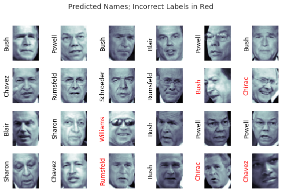

```python
# check some test images along with their predicted values:
fig, ax = plt.subplots(4, 6, figsize=(10,6))
for i, axi in enumerate(ax.flat):
    axi.imshow(Xtest[i].reshape(62, 47), cmap='bone')
    axi.set(xticks=[], yticks=[])
    axi.set_ylabel(faces.target_names[yfit[i]].split()[-1],
                   color='black' if yfit[i] == ytest[i] else 'red')
fig.suptitle('Predicted Names; Incorrect Labels in Red', size=14);
```

We can get a better sense of our estimator's performance using the `classification report`, which lists recovery statistics label by label:

```python
from sklearn.metrics import classification_report
print(classification_report(ytest, yfit,
                            target_names=faces.target_names))
```

```
                   precision    recall  f1-score   support

     Ariel Sharon       0.71      0.75      0.73        16
     Colin Powell       0.85      0.92      0.88        66
  Donald Rumsfeld       0.58      0.81      0.68        27
    George W Bush       0.95      0.81      0.87       140
Gerhard Schroeder       0.73      0.79      0.76        24
      Hugo Chavez       0.93      0.76      0.84        17
   Jacques Chirac       0.58      0.70      0.64        10
    Jean Chretien       0.73      0.79      0.76        14
    John Ashcroft       0.82      0.88      0.85        16
Junichiro Koizumi       0.89      0.73      0.80        11
  Serena Williams       0.70      0.78      0.74         9
       Tony Blair       0.83      0.85      0.84        40

        micro avg       0.82      0.82      0.82       390
        macro avg       0.77      0.80      0.78       390
     weighted avg       0.84      0.82      0.83       390
```

We might also display the `confusion matrix` between these classes:

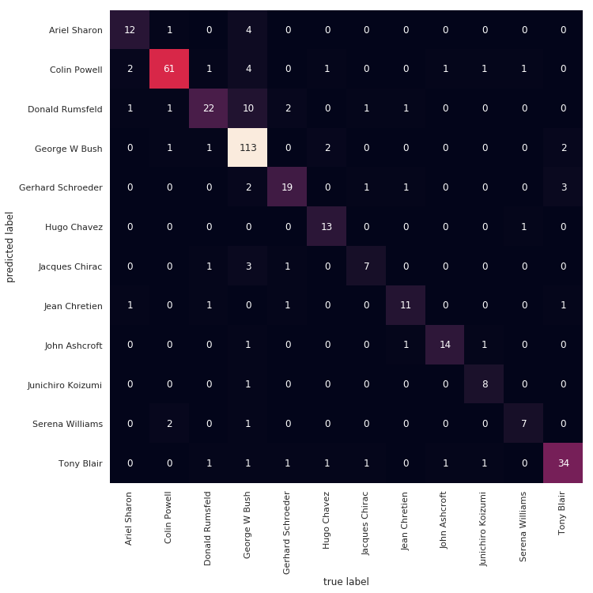

```python
from sklearn.metrics import confusion_matrix
mat = confusion_matrix(ytest, yfit)

fig, ax = plt.subplots(figsize=(11,11))
ax = sns.heatmap(mat.T, square=True, annot=True,
            fmt='d', cbar=False,
            xticklabels=faces.target_names,
            yticklabels=faces.target_names)
plt.xlabel('true label')
plt.ylabel('predicted label');
```

For a real-world facial recognition task, in which the photos do not come `pre-cropped` into nice grids, the only difference in the facial classification scheme is the `feature selection`: you would need to use a more sophisticated algorithm to find the faces, and extract features that are independent of the pixellation.

For this kind of application, one good option is to make use of `OpenCV`, which, among other things, includes pre-trained implementations of state-of-the-art feature extraction tools for images in general and faces in particular.

### More recent advances: Deep Learning

Histogram of Gradients (`HOG`) and other procedural feature extraction methods for images are no longer state-of-the-art techniques. Instead, many modern object detection pipelines use variants of deep neural networks